# STA211 : Recherche de règles d’association

Vincent Audigier, Ndeye Niang

05 mars, 2026

# 1 Introduction

Les méthodes de recherche de règles d’association ont été proposées pour découvrir quels produits étaient achetés conjointement et à quelle date dans les bases de données des ventes de supermarché (Agrawal, Imieliński, and Swami (1993)). Elles permettent d’extraire des règles de type : “lorsqu’un client achète du pain et du beurre alors 9 fois sur 10 il achète en même temps du lait”. En effet, la technologie des codes-barres permet l’acquisition rapide et automatique des données relatives aux ventes. Trouver des ensembles d’articles achetés simultanément permet alors de mener des actions marketing pertinentes. Cependant, même si initialement la méthode de recherche de règles d’association a été développée dans un objectif marketing, elle peut être appliquée dans d’autres domaines si la structure des données s’y prête. Elle peut trouver des applications notamment en “webmining” dans l’analyse de la consultation des pages web sur un site Internet, ou encore en “text mining” dans la découverte de cooccurrences de termes dans les documents.

Cette section s’appuiera sur la thèse de Marie Plasse (Plasse (2006)) à laquelle le lecteur pourra se référer au besoin pour des approfondissements.

# 2 Quelques définitions et concepts de base

On définit l’ensemble $I=\{it_1,it_2,.,it_i,.,it_p\}$ dont les éléments sont appelés **items**. $I$ peut par exemple correspondre à l’ensemble des produits d’un supermarché. On appelle alors **transaction**, un sous-ensemble non-vide de **I**. Dans l’exemple précédent, une transaction correspond au contenu d’un caddie. On note $T=\{ tr_1,tr_2,.,tr_j,.,tr_n\}$ l’ensemble à $n$ éléments des transactions, dans l’exemple précédent, il s’agit d’un ensemble de $n$ contenus de caddies.

Une règle d’association est une implication de la forme $A\rightarrow B$ où $A\subset I$, $B\subset I$ et $A\cap B=\emptyset$. Une règle comporte donc une partie **prémisse** (ou **antécédent**) composée d’un ensemble d’items $A$ et une partie **conclusion** (ou **conséquent**) composée d’un ensemble d’items $B$ disjoint de $A$. Les ensembles d’items sont appelés **itemsets**. Par exemple, la règle $\{ cacahuètes, chips, pastis\} \rightarrow \{ bière\}$ a pour prémisse $\{ cacahuètes, chips, pastis\}$ et pour conséquent $\{ bière\}$, chacun correspondant à un *itemset* de taille 3 et 1 respectivement.

## 2.1 Représentation et lecture des données

Tous les *itemsets* des transactions peuvent être représentés par un treillis d’items formé de l’ensemble des parties de l’ensemble I muni de l’opération d’inclusion. La figure ci-dessous montre un exemple de treillis associé à un ensemble de 4 items.

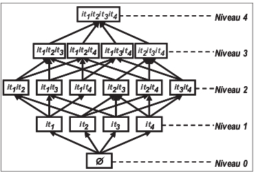